# Window Analysis of Genomic Diversity

Alejandro Thérèse Navarro

August 7, 2017

#### Loading data and basic descriptives

Using the simulated datafile 11 multiple genomic diversity analysis will be performed using sliding windows analysis.

```r
library(PopGenome)

#first we load data from adjacent folder that contains SNPs
simulation <- readData(path = "simulation",format="Fasta",SNP.DATA = T,progress_bar_switch=F)
position <- unlist(read.table("sweep_posID11.txt")) #associate data with positions
simulation <- set.ref.positions(simulation,list(position))
```

Let’s look at our data. We will want to know the number of individuals analyzed, the number of sites scanned and the number of SNPs.

```r
snps<-length(position)#this gives us the range of sites scanned
print(snps)
```

```
## [1] 2108
```

```r
individuals<-length(simulation@region.data@populations[[1]][[1]])#this gives us the number of haplotypes in our data.
print(individuals) #We don't know why, but this is giving, in windows, 60 individuals rather than 30 (?)
```

```
## [1] 60
```

```r
rangeSNP<-range(simulation@region.data@biallelic.sites)#this gives us the length of bp covered by our SNP data
print(rangeSNP)
```

```
## [1]    16 99890
```

## Sliding windows statistics

To calculate the sliding windows we will need to use the range of SNPs we are working with, that is in the `rangeSNP` object.

```r
#definition of sliding windows
size_sw<-8000 #we set the length of the windows to be analyzed
sim_sw<- sliding.window.transform(simulation,width=size_sw,
                                   jump=size_sw,start.pos = rangeSNP[1],
                                   end.pos =rangeSNP[2], type=2,whole.data=TRUE)
```

Afterwards, we will calculate $\Pi$ (theta_Tajima), $\theta_w$ (theta_Watterson) and Tajima’s $D$ (Tajima.D). We do this with `neutrality.stats`, which actually calculates a ton of statistical measures, we can obtain them with. We will see a whole table with the `summary` function, with the calculations of each parameter for the 8kB windows.

```r
sim_sw <- neutrality.stats(sim_sw) #this adds into the sim_sw GENOME file a series of diversity statistics, including
```

```r
lapply(get.neutrality(sim_sw,theta=T),summary) #if we apply the summary function to the list of results we have observed with the lapply function, we can see a set of summaries of all the indexes calculated.
```

```
## [[1]]
##     Tajima.D       n.segregating.sites   Rozas.R_2      Fu.Li.F
##  Min.   :-0.5977   Min.   :149.0       Min.   : NA   Min.   :1.370
##  1st Qu.:-0.4463   1st Qu.:158.5       1st Qu.: NA   1st Qu.:1.444
##  Median :-0.4264   Median :173.0       Median : NA   Median :1.454
##  Mean   :-0.4020   Mean   :168.4       Mean   :NaN   Mean   :1.465
##  3rd Qu.:-0.3637   3rd Qu.:176.8       3rd Qu.: NA   3rd Qu.:1.478
##  Max.   :-0.1594   Max.   :182.0       Max.   : NA   Max.   :1.583
##                                        NA's   :12
##     Fu.Li.D          Fu.F_S       Fay.Wu.H       Zeng.E      Strobeck.S
##  Min.   :2.254   Min.   : NA   Min.   : NA   Min.   : NA   Min.   : NA
##  1st Qu.:2.262   1st Qu.: NA   1st Qu.: NA   1st Qu.: NA   1st Qu.: NA
##  Median :2.272   Median : NA   Median : NA   Median : NA   Median : NA
##  Mean   :2.269   Mean   :NaN   Mean   :NaN   Mean   :NaN   Mean   :NaN
##  3rd Qu.:2.275   3rd Qu.: NA   3rd Qu.: NA   3rd Qu.: NA   3rd Qu.: NA
##  Max.   :2.278   Max.   : NA   Max.   : NA   Max.   : NA   Max.   : NA
##                  NA's   :12    NA's   :12    NA's   :12    NA's   :12
##   theta_Tajima   theta_Watterson  theta_Fu.Li theta_Achaz.Watterson
##  Min.   :28.00   Min.   :31.95   Min.   :0    Min.   :40.86
##  1st Qu.:29.49   1st Qu.:33.99   1st Qu.:0    1st Qu.:43.47
##  Median :32.92   Median :37.10   Median :0    Median :47.45
##  Mean   :32.01   Mean   :36.12   Mean   :0    Mean   :46.19
##  3rd Qu.:33.31   3rd Qu.:37.90   3rd Qu.:0    3rd Qu.:48.47
##  Max.   :36.65   Max.   :39.03   Max.   :0    Max.   :49.91
##
##   theta_Fay.Wu   theta_Zeng  theta_Achaz.Tajima
##  Min.   : NA   Min.   : NA   Min.   :28.98
##  1st Qu.: NA   1st Qu.: NA   1st Qu.:30.52
##  Median : NA   Median : NA   Median :34.07
##  Mean   :NaN   Mean   :NaN   Mean   :33.13
##  3rd Qu.: NA   3rd Qu.: NA   3rd Qu.:34.48
##  Max.   : NA   Max.   : NA   Max.   :37.94
##  NA's   :12    NA's   :12
```

We will calculate the $CLR$ values as well.

```r
sim_sw<- detail.stats(sim_sw)
freq1 <- table(unlist(sapply(sim_sw@region.stats@minor.allele.freqs,function(x){return(x[1,])})))
sim_sw<- sweeps.stats(sim_sw,freq.table=list(freq1))
CLRdata<-sim_sw@CLR
```

#### Plotting statistics

We can plot the estimated parameters per window, to have an idea of what regions might be affected by a selective sweep.

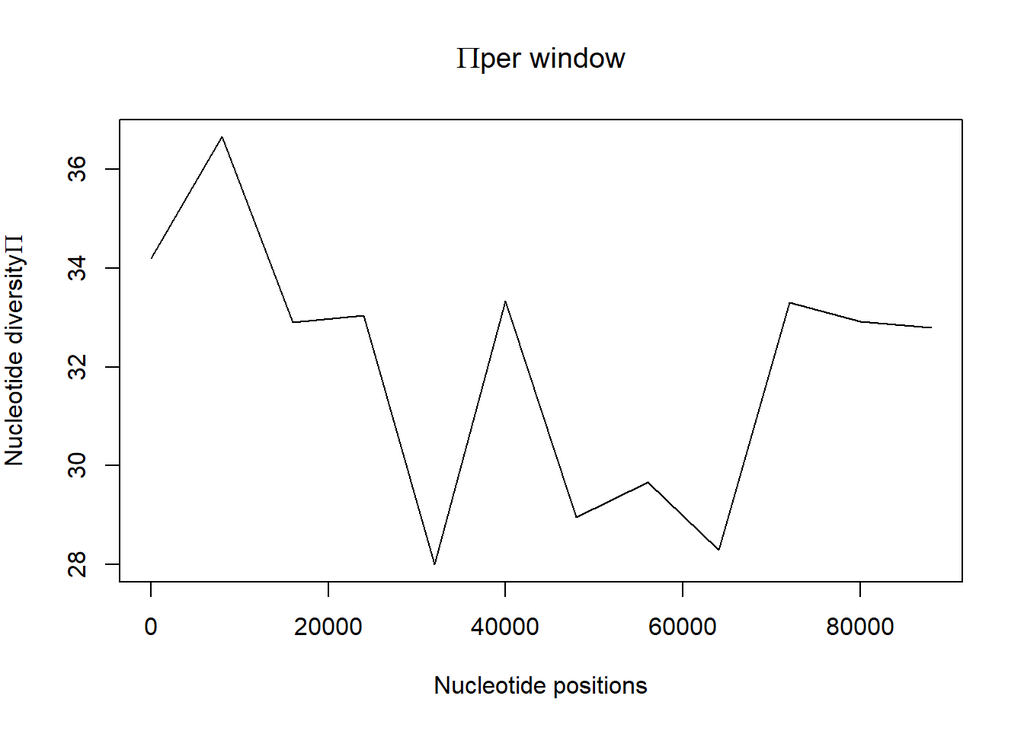

```r
xaxis <- strsplit(sim_sw@region.names,split=" : ")#we obtain the names of the window margins
xaxis <- sapply(xaxis,function(x){as.numeric(strsplit(x,split=" ")[[c(1,1)]])})#we put them into xaxis object

plot(xaxis,sim_sw@theta_Tajima,type="l",ylab=expression(paste("Nucleotide diversity ",Pi)),xlab="Nucleotide positions",main=expression(paste(Pi,"per window")))
```

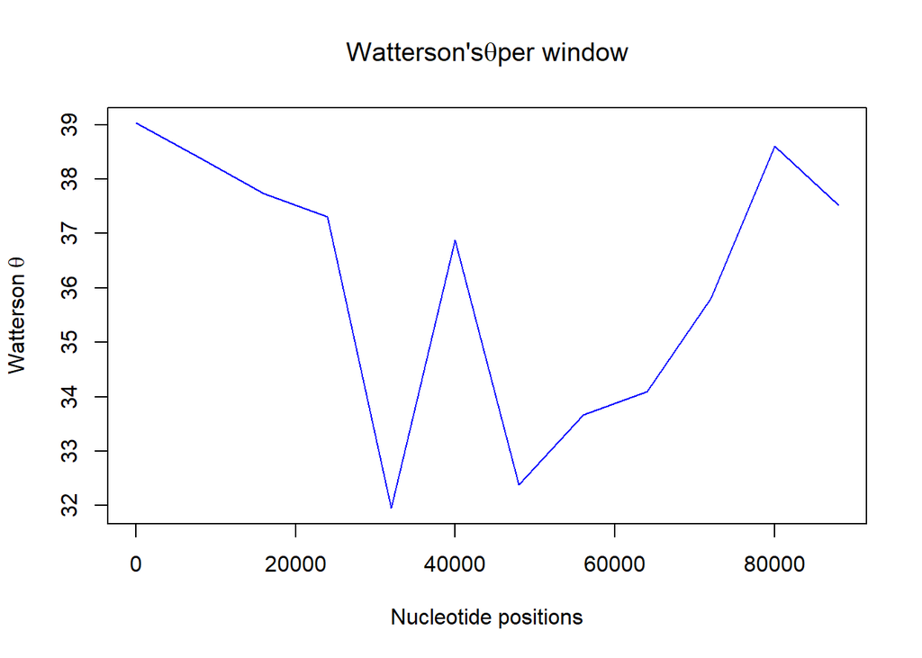

```r
plot(xaxis,sim_sw@theta_Watterson,type="l",col="blue",ylab=expression(paste("Watterson ",theta)),xlab="Nucleotide positions",main=expression(paste("Watterson's",theta,"per window")))
```

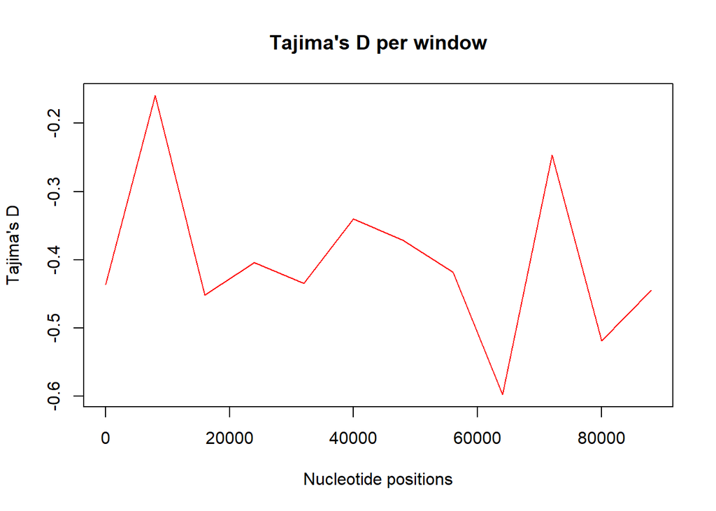

```r
plot(xaxis,sim_sw@Tajima.D,type="l",col="red",ylab="Tajima's D",xlab="Nucleotide positions",main="Tajima's D per window")
```

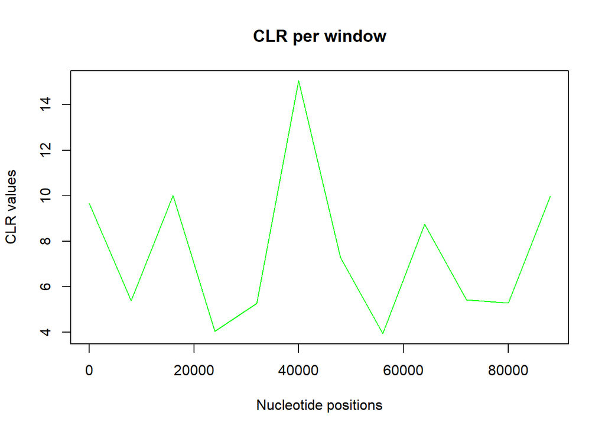

```r
plot(xaxis,CLRdata,type="l",col="green",ylab="CLR values",xlab="Nucleotide positions",main="CLR per window")
```

It is important to know that $\Pi$, $\theta_w$ and Tajima’s $D$ indicate a selective sweep in zones where the value drops, while it is peaks in the $CLR$ what indicates a selective sweep. From this analysis we see that there might be a sweep between ~20000bp and ~60000bp. However, it would be better to be able to compare directly the measurements. ####Comparison plots Generating overlapping plots of the four measurments is complex due to different mean values and different range of each index. Therefore, it will be useful to compare which are the most extreme values obtained by each estimator. If we plot which windows have had the lowest score (or highest in case of the $CLR$), we will be able to better decide which windows have a higher indication of being under selective sweep.

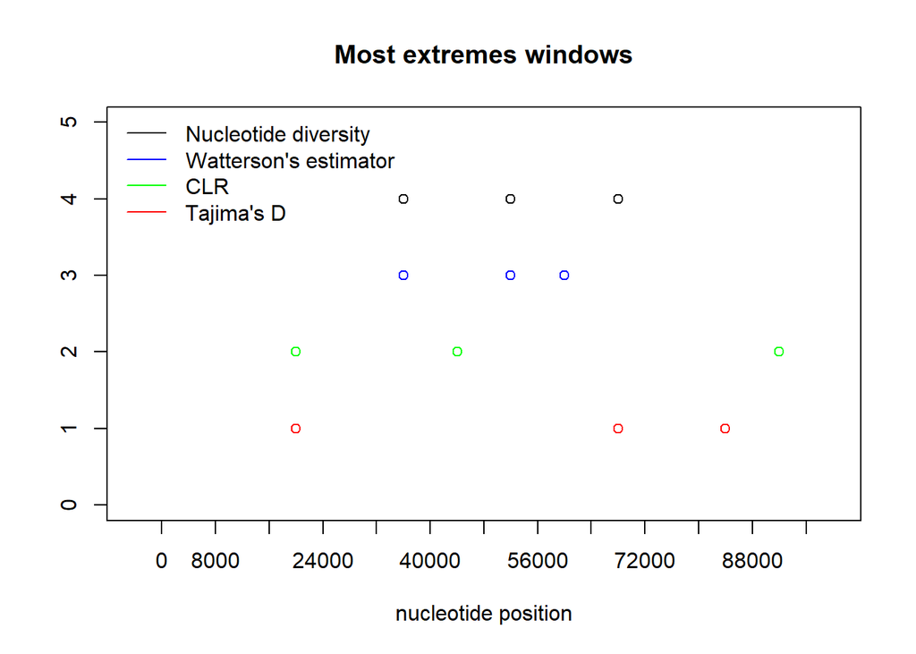

```r
top<-3 #we establish the top extreme values that we will choose

#Each of these lines selects window number in which the estimates are equal or smaller (except for CLR, where we take the highest) to the 5th most extreme value of the estimator. This will be the points we want to plot.
cand_pi <- which(sim_sw@theta_Tajima<=sort(sim_sw@theta_Tajima)[top])
cand_watt <- which(sim_sw@theta_Watterson<=sort(sim_sw@theta_Watterson)[top])
cand_tajD <- which(sim_sw@Tajima.D<=sort(sim_sw@Tajima.D)[top])
cand_clr <- which(sim_sw@CLR>=sort(sim_sw@CLR,decreasing=TRUE)[top])

num_sw<-c(0:length(sim_sw@region.names)) #for certain graph parameters it is useful to have a vector containing the window numbers

#We will plot points at the most extreme windows
plot(cand_pi,rep(4,length(cand_pi)),col="black",ylim=c(0,5),xlim=c(0,max(num_sw)+1),xlab="nucleotide position",ylab="",xaxt="n",main="Most extremes windows")
points(cand_clr,rep(2,length(cand_clr)),col="green")
points(cand_tajD,rep(1,length(cand_tajD)),col="red")
points(cand_watt,rep(3,length(cand_watt)),col="blue")
#we add some axes and legends
axes_sw<-c(size_sw*num_sw)#we create axes labels that contain the limits of each window
axis(1,num_sw,labels=axes_sw,at=num_sw+0.5,tick=T)#the labels are plotted so that the points are plotted in the middle of two axis ticks
legend("topleft",legend=c("Nucleotide diversity","Watterson's estimator","CLR","Tajima's D"),col=c("black","blue","green","red"),lty=c(1,1,1,1),bty="n")
```

From the obtained plot we can see that $\Pi$ and Watterson’s $\theta$ seem to point to the region between 32000bp and 72000bp. However, both Tajima’s $D$ and $CLR$ seem to be randomly distributed, pointing at spread regions across our sequences.

### Simulation data analysis

Because of the conflictivity of our results, obtaining a **p-value** that more definately tells us whether there are selective sweeps would be nice. Using Monte Carlo theory, we can generate a *null hypothesis distribution*, so to speak. For that we will simulate a population without selection using the program `msprime`. We can compare how the observed values fit with the null distribution, allowing us to evaluate whether what we observe indicates a selective sweep.

[figure not shown]

```r
load("sim_tp/sim_sweepstatsID11.RData") #loading of the simulation objects

#How to make an approx. Monte Carlo test
thres_clr<-sort(sim_sw@CLR,decreasing=TRUE)[top]#the threshold of CLR values (our top most extreme CLR value)
data_null <- c(clr_max_sim,thres_clr)
clr_p <- sum(data_null>=thres_clr)/length(data_null)#shouldn't the p-value be calculated including all the values over the threshold in the "real data"?

#plot CLR
plot(density(clr_max_sim),type="l",xlim=c(min(density(clr_max_sim)$x,density(sim_sw@CLR)$x),
                                          max(density(clr_max_sim)$x,density(sim_sw@CLR)$x)),
     ylim=c(0,max(density(clr_max_sim)$y,density(sim_sw@CLR,na.rm=T)$y)),
     xlab="CLR values",main="Simulated and Observed CLR",sub=paste("Monte Carlo p-value test =",round(clr_p,digits=2)))
points(density(sim_sw@CLR,na.rm=TRUE),type="l",col="red",lty=2) #The "real data"
abline(v=thres_clr,col="red") #the threshold of the candidate windows
legend("topright",legend=c("5th biggest CLR observed","CLR observed","maximum CLR under SNM (via simulation)"),col=c("red","red","black"),lty=c(1,2,1))
```

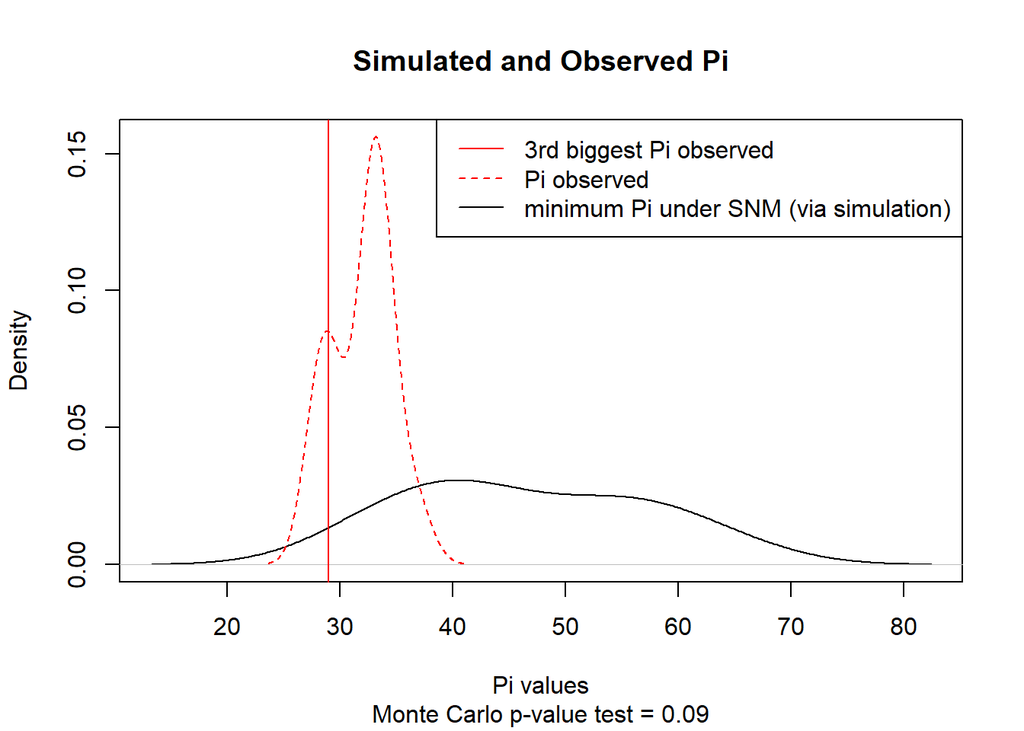

```r
#we can do the same procedure with nucleotide diversity
thres_Pi<-sort(sim_sw@theta_Tajima)[top]
data_null_Pi<-c(pi_min_sim,thres_Pi)
Pi_p<-sum(data_null_Pi<=thres_Pi)/length(data_null_Pi)

#plot Pi
plot(density(pi_min_sim),type="l",xlim=c(min(density(pi_min_sim)$x,density(sim_sw@theta_Tajima)$x),
                                          max(density(pi_min_sim)$x,density(sim_sw@theta_Tajima)$x)),
     ylim=c(0,max(density(pi_min_sim)$y,density(sim_sw@theta_Tajima,na.rm=T)$y)),
     xlab="Pi values",main="Simulated and Observed Pi",sub=paste("Monte Carlo p-value test =",round(Pi_p,digits=2)))
points(density(sim_sw@theta_Tajima,na.rm=TRUE),type="l",col="red",lty=2) #The "real data"
abline(v=thres_Pi,col="red") #the threshold of the candidate windows
legend("topright",legend=c("3rd biggest Pi observed","Pi observed","minimum Pi under SNM (via simulation)"),col=c("red","red","black"),lty=c(1,2,1))
```

Analysing both the $CLR$ and $Pi$ simulated distributions we see that there is no evidence for a selective sweep (both **p-values over** 0.05). Importantly, the “extreme” values are to the right in the $CLR$ graph and to the lefth in the $Pi$ graph.

Therefore, we can say that in the fasta files analyzed there is no evidence of selective sweeps.